# Nuevas Variables

# Comportamiento histórico

Sumaremos información a los individuos en función del comportamiento, para esto trabajaremos con un grupo de variables.

```r
df <- data.frame()

periodos <- c("201802","201801","201712","201711","201710","201709")
periodos <- sort(periodos)
for (pp in periodos) {
  df <- rbind(df, fread(paste0("C:/Users/saralb/Desktop/UBA/DropBox/UBA2018_20180803/datasets/dias/",pp,"_dias.txt"),
                        header=TRUE, sep="\t")[,c("foto_mes","numero_de_cliente","clase_ternaria", "mcuentas_saldo","mcuenta_corriente_Paquete","mpasivos_margen", "mcaja_ahorro_Paquete","cliente_edad")])
}
```

Veamos como varia el valor de la variable para una persona.

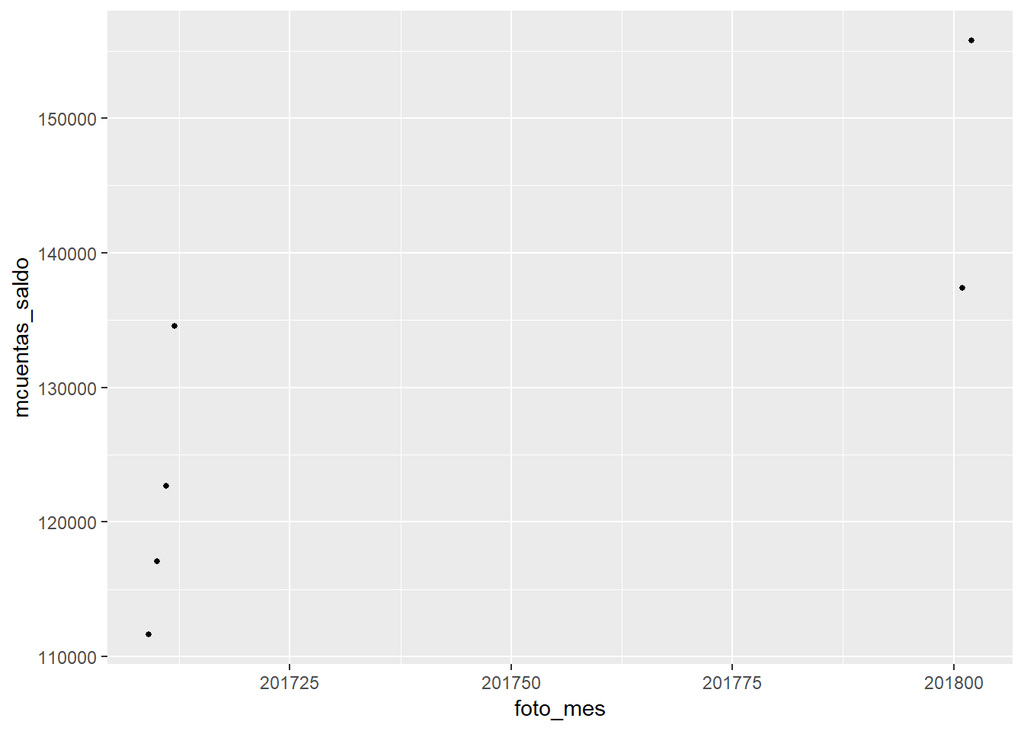

```r
# Tomamos una persona al azar que sea clase continua y que sea clase BAJA+x


library(ggplot2)

cliente <- df %>%
            filter(foto_mes == 201802) %>%
            # filter(clase_ternaria == "CONTINUA") %>%
            select(numero_de_cliente) %>%
            sample_n(1)

ggplot(df[df$numero_de_cliente == cliente$numero_de_cliente,], aes(x = foto_mes, y = mcuentas_saldo)) + geom_point( size=1)
```

Vemos que las fechas nos juegan una mala pasada, calculamos una nueva variable para visualizar de forma correcta.

Ejecute numerosas veces para ver los distintos comportamientos de los diferentes clientes y con diferentes variables:

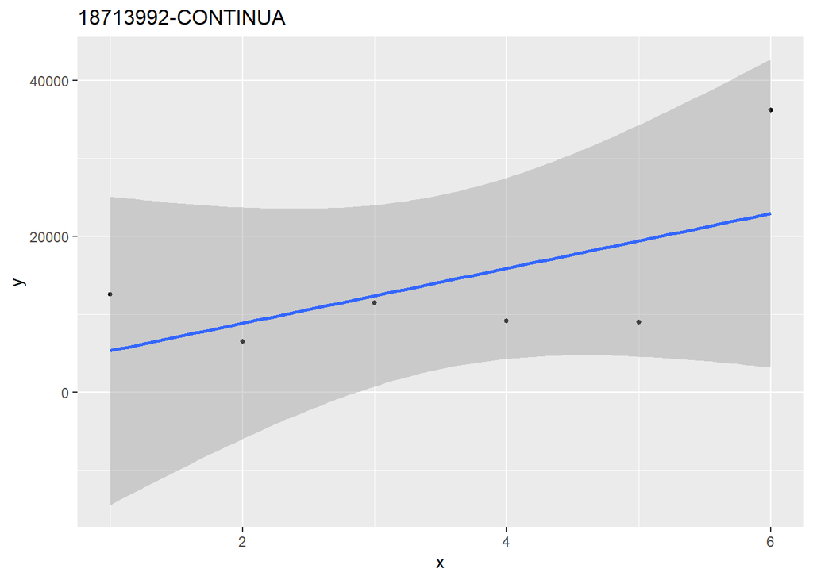

```r
variable <- "mcaja_ahorro_Paquete"
cliente <- df %>%
            filter(foto_mes == 201802) %>%
            # filter(clase_ternaria != "CONTINUA") %>%
            select(numero_de_cliente, clase_ternaria) %>%
            sample_n(1)


data <- df[df$numero_de_cliente == cliente$numero_de_cliente,]
data$x <- 1:nrow(data)
data$y = data[[variable]]

ggplot(data, aes(x = x,
                y = y)) +
  geom_point( size=1) +
  geom_smooth(method = "lm") +
  ggtitle(paste0(cliente$numero_de_cliente, "-", cliente$clase_ternaria))
```

Sumamos algunas métricas para comparar:

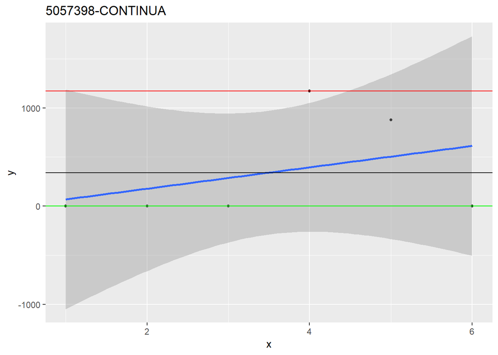

```r
variable <- "mcaja_ahorro_Paquete"
cliente <- df %>%
            filter(foto_mes == 201802) %>%
            # filter(clase_ternaria != "CONTINUA") %>%
            select(numero_de_cliente, clase_ternaria) %>%
            sample_n(1)


data <- df[df$numero_de_cliente == cliente$numero_de_cliente,]
data$x <- 1:nrow(data)
data$y = data[[variable]]

max_data = max(data[[variable]])
min_data = min(data[[variable]])
avg_data = mean(data[[variable]])

ggplot(data, aes(x = x,
                y = y)) +
  geom_point( size=1) +
  geom_smooth(method = "lm") +
  ggtitle(paste0(cliente$numero_de_cliente, "-", cliente$clase_ternaria)) +
  geom_hline(yintercept=max_data, color='red') +
  geom_hline(yintercept=avg_data, color='black') +
  geom_hline(yintercept=min_data, color='green')
```

Con nuestras observaciones, vamos a sumar algunas variables a nuestro modelo con información historica sobre los clientes, y vamos a medir su calidad.

```r
# Variable suelta:
data <- (df %>% filter(foto_mes == 201802))$mcaja_ahorro_Paquete

target <- (df %>% filter(foto_mes == 201802) %>%
                mutate(target = ifelse(clase_ternaria == "BAJA+2",1,0)))$target

modelar(data, target)
```

```
## [10:32:37] Tree method is selected to be 'hist', which uses a single updater grow_fast_histmaker.
## [10:32:37] Tree method is selected to be 'hist', which uses a single updater grow_fast_histmaker.
## [10:32:37] Tree method is selected to be 'hist', which uses a single updater grow_fast_histmaker.
## [10:32:37] Tree method is selected to be 'hist', which uses a single updater grow_fast_histmaker.
## [10:32:37] Tree method is selected to be 'hist', which uses a single updater grow_fast_histmaker.
```

```
## [1] 0.8213084
```

Y un conjunto de datos con las variables agregadas:

```r
data_agregada <- df %>%
           arrange(numero_de_cliente,foto_mes) %>%
           group_by(numero_de_cliente) %>%
           summarise(pp = max(foto_mes),
                     mcaja_ahorro_Paquete_mean = mean(mcaja_ahorro_Paquete),
                     mcaja_ahorro_Paquete_min = max(mcaja_ahorro_Paquete),
                     mcaja_ahorro_Paquete_max = min(mcaja_ahorro_Paquete)
                    ) %>%
            filter(pp == 201802) %>%
            select(mcaja_ahorro_Paquete_mean,
                   mcaja_ahorro_Paquete_max,
                   mcaja_ahorro_Paquete_min)


modelar(data_agregada, target)
```

```
## [10:32:43] Tree method is selected to be 'hist', which uses a single updater grow_fast_histmaker.
## [10:32:43] Tree method is selected to be 'hist', which uses a single updater grow_fast_histmaker.
## [10:32:43] Tree method is selected to be 'hist', which uses a single updater grow_fast_histmaker.
## [10:32:43] Tree method is selected to be 'hist', which uses a single updater grow_fast_histmaker.
## [10:32:43] Tree method is selected to be 'hist', which uses a single updater grow_fast_histmaker.
```

```
## [1] 0.814965
```

Por último probamos con el cálculo de una función personalizada para realizar la agregación:

```r
# Propia: porcentaje de variación entre los dos últimos meses
mi_agg <- function(x) {
  n <- length(x)
  if (n == 1) {
    return(NA)
  }
  x[n]/x[n-1]*100
}

data_mi_agg <- df %>%
           arrange(numero_de_cliente,foto_mes) %>%
           group_by(numero_de_cliente) %>%
           summarise(pp = max(foto_mes),
                     mcaja_ahorro_Paquete_porc = mi_agg(mcaja_ahorro_Paquete)) %>%
            filter(pp == 201802)
```

Notar que tarda su tiempo en realizar el cálculo. Se puede hacer más rápida la función?

- `View(lag)` podemos ver una implementación de una función bastante performante.

Lo más importante es poder ver que aplicamos bien la función, validando con casos de ejemplo. Se suelen cometer muchos errores por problemas de código.

```r
# Tomamos un cliente al azar y auditamos los resultados

cliente <- (df %>%
            filter(foto_mes == 201802) %>%
            sample_n(1))$numero_de_cliente

df %>% filter(numero_de_cliente == cliente) %>%
      select(numero_de_cliente, foto_mes, mcaja_ahorro_Paquete)
```

| numero_de_cliente | foto_mes | mcaja_ahorro_Paquete |
| --- | --- | --- |
| 5997790 | 201709 | 1276665 |
| 5997790 | 201710 | 1416361 |
| 5997790 | 201711 | 1426226 |
| 5997790 | 201712 | 1526452 |
| 5997790 | 201801 | 1413024 |
| 5997790 | 201802 | 1365110 |

```r
data_mi_agg %>% filter(numero_de_cliente == cliente)
```

| numero_de_cliente | pp | mcaja_ahorro_Paquete_porc |
| --- | --- | --- |
| 5997790 | 201802 | 96.60914 |

Sabiendo que está bien calculada, pasamos a medir su potencia:

```r
modelar(data_mi_agg, target)
```

```
## [10:33:01] Tree method is selected to be 'hist', which uses a single updater grow_fast_histmaker.
## [10:33:02] Tree method is selected to be 'hist', which uses a single updater grow_fast_histmaker.
## [10:33:02] Tree method is selected to be 'hist', which uses a single updater grow_fast_histmaker.
## [10:33:02] Tree method is selected to be 'hist', which uses a single updater grow_fast_histmaker.
## [10:33:02] Tree method is selected to be 'hist', which uses a single updater grow_fast_histmaker.
```

```
## [1] 0.7652528
```

- ¿Qué otras variables de agregadas considera que son buenas predictoras?